# Plastic Collection: Global and Nigeria

Total Plastic Collected Summary by Continent

| Continent | Annual Mean Temp (°C) | Total Plastic Collected Mean | Total Plastic Collected Median | Total Plastic Collected SD |
| --- | --- | --- | --- | --- |
| Europe | 11.59 | 4,857.39 | 1,380 | 9,624.88 |
| Americas | 16.90 | 4,862.65 | 2,033 | 6,598.42 |
| Oceania | 22.67 | 837.00 | 837 | 1,175.21 |
| Asia | 22.68 | 8,838.89 | 1,663 | 17,591.19 |
| Africa | 24.59 | 17,640.00 | 4,922 | 38,724.10 |

Country-Level Temperature and Total Plastic by Continent

[figure not shown]

Total Plastic Collected Summary Across Temperature Bins

| Annual Mean Temp (°C) | Total Plastic Collected Mean | Total Plastic Collected Median | Total Plastic Collected SD |
| --- | --- | --- | --- |
| <10°C | 8,204.64 | 2,033 | 15,325.73 |
| 10–15°C | 3,018.69 | 1,067 | 3,850.23 |
| 15–20°C | 2,105.60 | 972 | 2,689.81 |
| 20–25°C | 5,501.09 | 2,319 | 8,276.40 |
| 25°C+ | 15,639.03 | 6,327 | 31,454.12 |

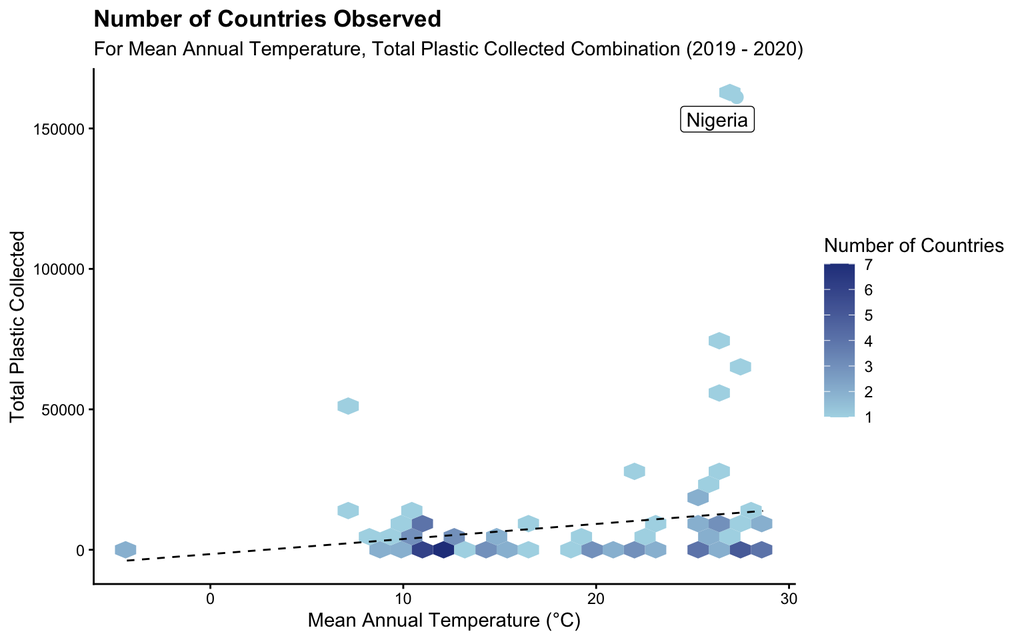

Figure 1.2. Hexbin plot of Mean Annual Temperature and Grand Total Plastic Collected (2019-2020)

Map of Nigeria

[interactive chart not shown]

Neighborhoods within Lagos

Click on a neighborhood to see the most common plastics collected from beach cleanups in Lagos!

[interactive chart not shown]

Why Nigeria?

Beach Clean Ups in Nigeria

We used information on beach plastic cleanups in Nigeria (specifically Lagos and Rivers) from 2017-2018 provided by The Earth Challenge, an app where volunteers document plastic pollution found in the environment.

Mean Temperatures in Lagos and Rivers

In 2018, WeatherSpark’s Lagos weather history reported data with Lagos showing consistently warm conditions, averaging 26.7°C. For Rivers State, Port Harcourt provides a climate reference that temperatures were typically around 25.7°C in 2018.

**Counts for the Top 3 Plastic Items Found in Lagos Beach Cleanups (2017-2018)**

**Plastic Bottles:**

2,886

**Bottle Caps:**

1,535

**Wrappers & Labels:**

1,162